EXERCISE 1 Consider the census data in Section 1.16.1. (a) Form an approximate 95% confidence interval for β6 in the model (1.28).

```r
lm21a <- lm(wageinc ~ age + age2 + wkswrkd + ms + phd + fem, data=prgeng)
summary(lm21a)
```

```
##
## Call:
## lm(formula = wageinc ~ age + age2 + wkswrkd + ms + phd + fem,
##     data = prgeng)
##
## Residuals:
##    Min     1Q Median     3Q    Max
## -98563 -20332  -4273  12781 290808
##
## Coefficients:
##              Estimate Std. Error t value Pr(>|t|)
## (Intercept) -81136.70    3284.75  -24.70   <2e-16 ***
## age           3900.35     168.77   23.11   <2e-16 ***
## age2           -40.33       1.95  -20.68   <2e-16 ***
## wkswrkd       1196.39      21.89   54.65   <2e-16 ***
## ms           15431.07     738.80   20.89   <2e-16 ***
## phd          23183.97    1626.70   14.25   <2e-16 ***
## fem         -11484.49     705.30  -16.28   <2e-16 ***
## ---
## Signif. codes:  0 '***' 0.001 '**' 0.01 '*' 0.05 '.' 0.1 ' ' 1
##
## Residual standard error: 42650 on 20083 degrees of freedom
## Multiple R-squared:  0.2356, Adjusted R-squared:  0.2354
## F-statistic:  1032 on 6 and 20083 DF,  p-value: < 2.2e-16
```

```r
confint(lm21a, "fem", level=0.95)
```

```
##         2.5 %    97.5 %
## fem -12866.93 -10102.05
```

95% confidence interval for β6 is -11484.49 +/- 1.96*705.30 = (-12866.88, -10102.05)

```r
lm21b <- lm(wageinc ~ age + age2 + wkswrkd + ms + phd + fem + ms:fem + phd:fem, data=prgeng)
summary(lm21b)
```

```
##
## Call:
## lm(formula = wageinc ~ age + age2 + wkswrkd + ms + phd + fem +
##     ms:fem + phd:fem, data = prgeng)
##
## Residuals:
##     Min      1Q  Median      3Q     Max
## -100361  -20374   -4247   12824  289893
##
## Coefficients:
##               Estimate Std. Error t value Pr(>|t|)
## (Intercept) -81216.778   3283.880 -24.732  < 2e-16 ***
## age           3894.320    168.735  23.080  < 2e-16 ***
## age2           -40.293      1.949 -20.669  < 2e-16 ***
## wkswrkd       1195.309     21.889  54.609  < 2e-16 ***
## ms           16433.668    846.655  19.410  < 2e-16 ***
## phd          25325.315   1759.281  14.395  < 2e-16 ***
## fem         -10276.797    804.498 -12.774  < 2e-16 ***
## ms:fem       -4157.253   1728.329  -2.405  0.01617 *
## phd:fem     -14061.635   4605.664  -3.053  0.00227 **
## ---
## Signif. codes:  0 '***' 0.001 '**' 0.01 '*' 0.05 '.' 0.1 ' ' 1
##
## Residual standard error: 42640 on 20081 degrees of freedom
## Multiple R-squared:  0.2361, Adjusted R-squared:  0.2358
## F-statistic: 775.9 on 8 and 20081 DF,  p-value: < 2.2e-16
```

```r
confint(lm21b, "ms:fem", level=0.95)
```

```
##           2.5 %    97.5 %
## ms:fem -7544.92 -769.5861
```

EXERCISE 2 The full bikeshare dataset spans 3 years’ time. Our analyses here have only used the first year. Extend the analysis in Section 2.8.5 to the full data set, adding dummy variables indicating the second and third year. Form an approximate 95% confidence interval for the difference between the coefficients of these two dummies. DATASET HAS ONLY 2 YEARS, so dummy already created as yr = 0 for 2011 and 1 for 2012

```r
shar <- read.csv("day.csv", header=TRUE)
shar$reg <- shar$registered
shar$temp2 <- shar$temp^2
shar$clearday <- as.integer(shar$weathersit == 1)
# lmBS <- lm(reg ~ season + yr + mnth + holiday + workingday + temp + temp2 + hum + windspeed + clearday , data = shar)
# taking out holiday and mnth as they are not significant
lmBS <- lm(reg ~ season + yr + workingday + temp + temp2 + hum + windspeed + clearday , data = shar)
summary(lmBS)
```

```
##
## Call:
## lm(formula = reg ~ season + yr + workingday + temp + temp2 +
##     hum + windspeed + clearday, data = shar)
##
## Residuals:
##     Min      1Q  Median      3Q     Max
## -4264.7  -294.7    60.1   392.7  1643.2
##
## Coefficients:
##             Estimate Std. Error t value Pr(>|t|)
## (Intercept) -1014.94     234.14  -4.335 1.67e-05 ***
## season        326.01      23.75  13.725  < 2e-16 ***
## yr           1681.16      47.98  35.036  < 2e-16 ***
## workingday    944.89      50.95  18.544  < 2e-16 ***
## temp        13024.46     811.34  16.053  < 2e-16 ***
## temp2       -9737.36     802.01 -12.141  < 2e-16 ***
## hum         -1696.68     226.09  -7.504 1.82e-13 ***
## windspeed   -2744.11     328.71  -8.348 3.52e-16 ***
## clearday      348.19      62.72   5.551 3.99e-08 ***
## ---
## Signif. codes:  0 '***' 0.001 '**' 0.01 '*' 0.05 '.' 0.1 ' ' 1
##
## Residual standard error: 637.5 on 722 degrees of freedom
## Multiple R-squared:  0.8349, Adjusted R-squared:  0.8331
## F-statistic: 456.4 on 8 and 722 DF,  p-value: < 2.2e-16
```

```r
confint(lmBS, "yr", level = 0.95) # (1586.951, 1775.361)
```

```
##       2.5 %   97.5 %
## yr 1586.951 1775.361
```

EXERCISE 3 Suppose we are studying growth patterns in children, at k particular ages. Denote the height of the ith child in our sample data at age j by Hij, with Hi = (Hi1,…,Hik)′ denoting the data for child i. Suppose the population distribution of each Hi is k-variate normal with mean vector μ and covariance matrix Σ. Say we are interested in successive differences in heights,Dij =Hi,j+1−Hij, j=1,2,…,k−1. DefineDi =(Di1,…,Dik)′. Explain why each Di is (k−1)-variate normal, and derive matrix expressions for the mean vector and covariance matrices.

EXERCISE 4 In the simulation in Section 2.9.3, it is claimed that ρ2 = 0.50. Confirm this through derivation.

```r
simr2 <- function (n , p , nreps ) {
  r2s <- vector(length=nreps)
  for (i in 1:nreps) {
    x <- matrix(rnorm(n*p),ncol=p)
    y <- x %*% rep(1,p) + rnorm(n,sd=sqrt(p))
    r2s[i] <- getr2(x,y)
  }
  hist(r2s)
}
getr2 <- function(x,y) {
  smm <- summary(lm(y ~ x))
  smm$r.squared
}
```

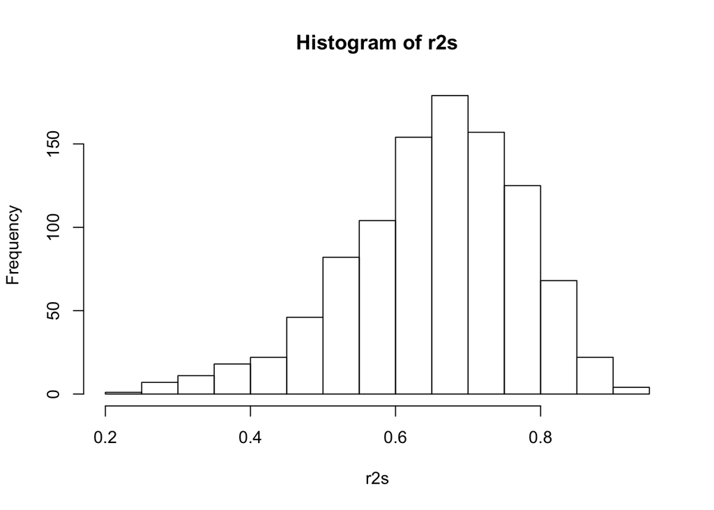

```r
simr2(25,8,1000)
```

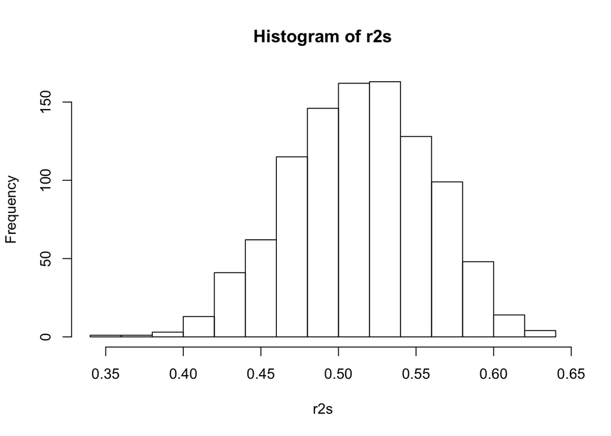

```r
simr2(250,8,1000)
```